# Chapter 1

Problems 1. a)

```r
# The number of phenotypic classes obtained (in general) is given by:
num_classes<-function(n){(2*n)+1}
n<-20 # The number of loci
num_classes(n)
```

[output not shown]

2. The probability of finding an individual among the offspring that is heterozygous at all 20 loci is the product of the probabilities at being heterozygous at 1 locus. N.B. We assume that they are unlinked (independent), and the parent is a heterozygote that is reproducing via selfing. Thus for a single locus the frequency of heterozygotes is 2/4 (0.5). So the frequency of heterozygotes at 20 loci is:

```r
0.5^n
```

```
[1] 9.536743e-07
```

3. The probability of obtaining descendants with a phenotypic value of 10 can be obtained using the binomial theorem.

```r
# R also has a function for this
dbinom(x = k, prob = p,size=(2*n))
```

```
[1] 0.0007709428
```

To get the full probability distribution we can compute the probabilities for all k = {0..40}. Again, we are mating two heterozygotes, so the allele frequencies are p = q = 0.5

```r
probabilities
```

```
 [1] 9.094947e-13 3.637979e-11 7.094059e-10 8.985808e-09 8.311872e-08 5.984548e-07 3.490986e-06 1.695622e-05 6.994440e-05
[10] 2.486912e-04 7.709428e-04 2.102571e-03 5.081214e-03 1.094415e-02 2.110658e-02 3.658474e-02 5.716365e-02 8.070163e-02
[19] 1.031187e-01 1.194007e-01 1.253707e-01 1.194007e-01 1.031187e-01 8.070163e-02 5.716365e-02 3.658474e-02 2.110658e-02
[28] 1.094415e-02 5.081214e-03 2.102571e-03 7.709428e-04 2.486912e-04 6.994440e-05 1.695622e-05 3.490986e-06 5.984548e-07
[37] 8.311872e-08 8.985808e-09 7.094059e-10 3.637979e-11 9.094947e-13
```

Plot this data

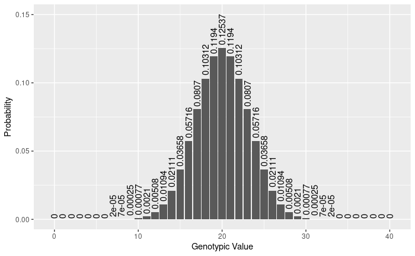

2. This is the data.

```r
bris<-c(24,24,21,21,21,20,19,19,18,24,
  23,25,22,24,22,22,18,20,22,28,
  23,27,23,20,23,21,26,27,27,28,
  26,26,24,26,27,26,20,22,21,18,
  18,21,17,21,18,20,23,22,34,22)
```

The phenotypic variance can be obtained simply from the phenotypic data. And we assume Vg = 4

```r
Vp<-var(bris)
Vg<-4
Ve<-Vp-Vg
```

Coefficients of variation for both P and G can be obtained with the mean of the phenotypic data. Since we assume that the mean of the genotypic values is the same as the mean of the phenotypic values.

```r
CVp<-sqrt(Vp)/(mean(bris))
CVg<-sqrt(Vg)/(mean(bris))
cat("Ve = ",Ve, ", CVp = ",CVp, ", CVg = ",CVg,"\n")
```

[output not shown]

Self Assessment Questions: 1. False 2. True 3. False 4. False 5. True 6. True 7. False 8. False 9. True 10. True